# Knapsack Problem

[figure not shown]

Qiskit Fall Fest Mexico 2021

$ \newcommand{\bra}[1]{\langle #1|} $ $ \newcommand{\ket}[1]{|#1\rangle} $ $ \newcommand{\braket}[2]{\langle #1|#2\rangle} $

Problema de la mochila

Por Claudia Zendejas-Morales

# Contenido

1. Introducción
   1. Modelo
   2. Problema de optimización
   3. Problema de la mochila 0-1
   4. Aplicaciones más allá del montañista
   5. Variantes del problema de la mochila
2. Enfoque clásico
   1. Ejemplo sencillo
3. Enfoque cuántico
   1. Módulo Qiskit Optimization
   2. Convertidores para programas cuadráticos
   3. Resolviendo con Qiskit
      1. Resolver con `NumPyMinimumEigensolver`
      2. Resolver con `QAOA`
      3. ¿Qué pasa con el Hamiltoniano?
      4. Resolver con `VQE`
4. Ejercicio: Inversiones
5. Referencias

# Introduction

Es fundamental que los humanos tomen decisiones todo el tiempo, con diferentes niveles de importancia y complejidad. Estas decisiones suelen estar basadas en emociones o gustos personales, sin embargo, no siempre podemos permitir que estas características subjetivas sean las que determinen los resultados de una decisión. Por tanto, una formulación cuantitativa que tenga en cuenta todos los factores que influyen en una decisión es algo deseado.

Para alcanzar este objetivo, debe ser posible representar el efecto de cualquier decisión mediante valores numéricos. En el caso más básico, el resultado de la decisión puede medirse mediante un único valor que represente la ganancia, el beneficio, la pérdida, el costo o alguna otra categoría de datos. La comparación de estos valores induce un orden total en el conjunto de todas las opciones que están disponibles para tomar una decisión. Encontrar la opción con el valor más alto o más bajo puede ser difícil porque el conjunto de opciones disponibles puede ser extremadamente grande y/o no conocido explícitamente.

La **forma más simple** posible de decisión es la **elección entre dos alternativas**. Dicha decisión se formula en un modelo cuantitativo con ayuda de una variable binaria,

$$x\in\{0,1\}$$

con el significado obvio de que $x=1$ indica tomar la primera alternativa mientras que $x=0$ indica el rechazo de la primera alternativa y, por tanto, la selección de la segunda opción.

En la versión básica de un modelo de decisión lineal, el resultado del proceso de decisión completo se evalúa mediante una combinación lineal de los valores asociados con cada una de las decisiones binarias. Para tener en cuenta las interdependencias por pares entre decisiones, también se puede utilizar una función cuadrática para representar el resultado de un proceso de decisión.

## Modelo

Hablando formalmente, el modelo de decisión lineal se define por $n$ **variables binarias** $x_j\in\{0,1\}$ que corresponden a la selección en la $j$-ésima decisión binaria y por los **valores de beneficio** $p_j$ que indican la diferencia de valor obtenida al elegir la primera alternativa, es decir, $x_j=1 $, en lugar de la segunda alternativa ($x_j = 0$). Sin pérdida de generalidad podemos suponer que después de una asignación adecuada de las dos opciones a los dos casos $x_j=1 $ y $x_j=0$, siempre tenemos $p_j\geq 0 $. El valor de beneficio general asociado con una elección particular para todas las decisiones binarias $N$ viene dado por la suma de todos los valores $p_j$ para todas las decisiones en las que se seleccionó la primera alternativa.

En este modelo, la viabilidad de una selección de alternativas está determinada por una restricción de capacidad de la siguiente manera. En cada decisión binaria $j$, la selección de la primera alternativa ($x_j=1$) requiere un **peso** o **recurso** $w_j$ mientras que elegir la segunda alternativa ($x_j=0$) no lo requiere. Una selección de alternativas es factible si la suma de pesos sobre todas las decisiones binarias no excede un valor de capacidad umbral dado, $W$ (a veces llamado $c$). Si se considera este proceso de decisión como un problema de optimización, donde el beneficio total debería ser lo más grande posible, se da el **problema de la mochila (Knapsack Problem, KP)**.

Esta característica del problema da lugar a la siguiente interpretación de KP, que es más colorida que la combinación de problemas de decisión binaria. Piensa en un montañista que está empacando su mochila (o knapsack) para un recorrido por la montaña y tiene que decidir qué artículos debe llevar consigo. Tiene una gran cantidad de objetos disponibles que pueden ser útiles en su recorrido. Cada uno de estos elementos numerados desde $1$ a $N$ le daría una cierta cantidad de comodidad o beneficio que se mide por un número positivo $p_j$. Por supuesto, el peso $w_j$ de cada objeto que el montañista pone en su mochila aumenta la carga que tiene que llevar. Por razones obvias, quiere limitar el peso total de su mochila y, por lo tanto, fija la carga máxima a un valor de capacidad $W$.

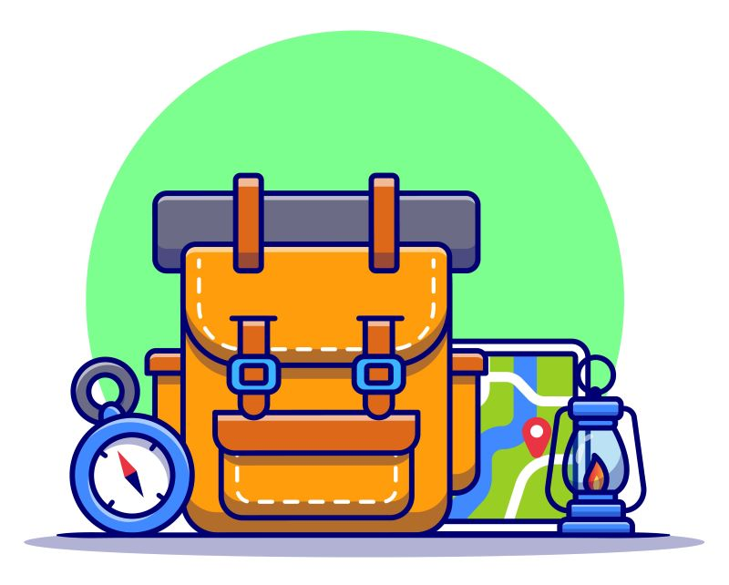

## Problema de optimización

En matemáticas, ciencias de la computación y economía, un problema de optimización es el problema de encontrar la mejor solución a partir de todas las soluciones factibles.

La forma estándar de un problema de optimización es

\begin{align*} \texttt{minimizar} \;\;\; &f(x)\\ \texttt{sujeto a} \;\;\; &g_i(x)\leq 0, \;\;\;\; i = 1,\cdots ,m\\ &h_j(x)=0, \;\;\;\; j = 1,\cdots ,p \end{align*}

Donde,

- $f:\mathbb{R}^n\rightarrow\mathbb{R}$ es la **función objetivo** a ser minimizada sobre el vector $x$ de $n$ variables
- $g_i(x)\leq 0$ son llamadas restricciones de desigualdad
- $h_j(x)= 0$ son llamadas restricciones de igualdad
- $m\geq 0$ y $p\geq 0$

Si $m=p=0$ el problema se trata de una optimización sin restriciones. Por convención, la forma estándar define un *problema de minimización*. Un *problema de maximización* puede ser abordado al multiplicar por $-1$ la función objetivo.

## Problema de la mochila 0-1

El problema de la mochila 0-1 (KP), que restringe el número $x_j$ de copias de cada tipo de artículo a cero o uno, se puede definir formalmente de la siguiente manera: Se nos da una instancia del problema de la mochila con el conjunto de artículos $N'=\{1,\dots,N\}$, que consta de $N$ elementos, el $j$-ésimo con beneficio $p_j$ y peso $w_j$, y el valor de capacidad $W$. (Por lo general, todos estos valores son números enteros positivos). Entonces, el objetivo es seleccionar un subconjunto de $N'$ de manera que la ganancia total de los artículos seleccionados se maximice y el peso total no exceda $W$.

\begin{align*} \texttt{maximizar} \;\;\; &\sum_{j=1}^{N}p_jx_j \label{eq:maximize} \tag{1}\\ \texttt{sujeto a} \;\;\; &\sum_{j=1}^{N}w_jx_j \leq W \;, \label{eq:subject_to} \tag{2}\\ &x_j\in\{0,1\} \; , \;\; j=1,\dots,N \label{eq:x_in_01_j} \tag{3}\\ \end{align*}

Denotemos el *vector de solución óptima* con $x^*=(x_i^*,\dots,x_N^*)$ y el *valor de solución óptima* por $z^*$. El conjunto $X^*$ denota el *conjunto de solución óptima*, es decir, el conjunto de elementos correspondientes al vector de solución óptima.

El problema KP es el modelo de programación de enteros no trivial más simple con variables binarias, solo una restricción y solo coeficientes positivos. Sin embargo, agregar la condición de integralidad $\eqref{eq:x_in_01_j}$ al programa lineal simple $\eqref{eq:maximize}$-$\eqref{eq:subject_to}$ ya coloca a KP en la clase de problemas "difíciles".

## Aplicaciones más allá del montañista

### Problema de inversión

Considerar la característica anterior del montañista en el contexto de los negocios en lugar del ocio conduce a una segunda interpretación clásica de KP como un problema de inversión. Un inversionista individual o institucional tiene una cierta cantidad de dinero $c$ disponible que quiere invertir en proyectos comerciales rentables. Como base para sus decisiones, compila una larga lista de posibles inversiones, la cantidad requerida de inversión $w_j$ y el rendimiento neto esperado $p_j$ durante un período fijo. Aquí no se tiene en cuenta explícitamente el aspecto del riesgo. Obviamente, KP puede formular la combinación de las decisiones binarias para cada inversión, de modo que el rendimiento general de la inversión sea lo más grande posible.

### Negocio de carga de aerolíneas

El operario de una aerolínea de carga tiene que decidir cuál de las solicitudes de transporte planteadas por los clientes debe cumplir, es decir, cómo cargar un avión en particular. Su decisión se basa en una lista de solicitudes que contiene el peso $w_j$ de cada paquete y la tarifa por unidad de peso cobrada por cada solicitud. Ten en cuenta que esta tarifa no es fija, sino que depende de los acuerdos particulares a largo plazo con cada cliente. Por lo tanto, la ganancia $p_j$ que obtiene la empresa al aceptar una solicitud y al colocar el paquete correspondiente en el avión no es directamente proporcional al peso del paquete. Naturalmente, cada avión tiene una capacidad máxima especificada $c$ que no puede ser superada por el peso total de los paquetes seleccionados. Este problema logístico es un análogo directo al embalaje de la mochila de los montañistas.

### Corte de troncos

Si bien todos los ejemplos anteriores contienen elementos de "empaquetado", también se puede ver el KP como un problema de "corte". Supón que un aserradero tiene que cortar un tronco en trozos más cortos. Sin embargo, las piezas deben cortarse en algunas longitudes estándar predefinidas $w_j$, donde cada longitud tiene un precio de venta asociado $p_j$. Para maximizar la ganancia del tronco, el aserradero puede formular el problema como un KP donde la longitud del tronco define la capacidad $c$.

## Variantes del problema de la mochila

Consideremos nuevamente el problema anterior del operario de aerolíneas de carga. En un escenario diferente, el beneficio obtenido al aceptar un paquete puede ser directamente proporcional a su peso. En este caso, la carga óptima del avión se logra llenando el avión con la mayor cantidad de peso posible o, de manera equivalente, estableciendo $p_j = w_j$ en KP. El problema de optimización resultante se conoce como **Problema de la suma de subconjuntos (Subset Sum Problem, SSP)** porque estamos buscando un subconjunto de los valores $w_j$ con la suma lo más cercana posible, pero sin exceder, el valor objetivo dado $c$. Reemplazando la función objetivo (1) en KP podemos definir SSP como:

$$\texttt {maximizar} \; \sum_{j=1}^{N} w_jx_j$$

Además, con frecuencia ocurrirá que no todos los paquetes son diferentes entre sí. En particular, en la práctica, se puede dar un número $b_j$ de copias idénticas de cada artículo a transportar. Si tenemos que aceptar una solicitud para todos los paquetes $b_j$ o rechazarlos todos, entonces podemos generar una solicitud artificial con el peso $b_jw_j$ generando una ganancia de $b_jp_j$. Si es posible seleccionar también solo un subconjunto de los elementos $b_j$ de una solicitud, podemos representar cada paquete individual mediante una variable binaria o representar de manera más eficiente el conjunto completo de paquetes idénticos mediante una variable entera $x_j \geq 0$ indicando el número de bultos de este tipo que se colocan en el avión. En este caso, el número de variables es igual al número de paquetes diferentes en lugar del número total de paquetes. Esto puede reducir considerablemente el tamaño del modelo si los números $b_j$ son relativamente grandes. El problema resultante se llama **Problema de la mochila acotado (Bounded Knapsack Problem, BKP)**. Formalmente, la restricción (3) en KP se reemplaza por:

$$0 \leq x_j\leq b_j, \; \; x_j \; \; \texttt {entero}, \; \; j=1, \dots, N$$

Una variante especial del mismo es el **Problema de la mochila no acotado (Unbounded Knapsack Problem, UKP)**. También se conoce como problema de la mochila entera donde en lugar de un número fijo $b_j$ se da una cantidad muy grande o infinita de copias idénticas de cada artículo. En este caso, la restricción (3) en KP simplemente se reemplaza por:

$$x_j \geq 0, \; \; x_j \; \; \texttt{entero}, \; \; j=1, \dots, N$$

Estos son solo algunos ejemplos de las variantes del problema de la mochila. El problema ha sido ampliamente estudiado y existen múltiples aplicaciones, las cuales son muy diversas e interesantes que se usan actualmente en muchas empresas.

# Enfoque clásico

Una solución simple es considerar todos los subconjuntos de artículos y calcular el peso total y el valor de todos los subconjuntos. Considera los únicos subconjuntos cuyo peso total es menor que $W$. De todos estos subconjuntos, elije el subconjunto de valor máximo. Esta es una *recursión con un algoritmo de fuerza bruta* o una *búsqueda exhaustiva*.

Como puedes estar imaginando, este enfoque ingenuo no es muy bueno, ya que los mismos subproblemas se calculan una y otra vez, generando redundancias. Tiene una complejidad de tiempo de $O\left(2^N\right)$ y un espacio auxiliar de $O(1)$.

Un mejor enfoque es usar la [Programación Dinámica (DP)](https://es.wikipedia.org/wiki/Programaci%C3%B3n_din%C3%A1mica#:~:text=En%20inform%C3%A1tica%2C%20la%20programaci%C3%B3n%20din%C3%A1mica,como%20se%20describe%20a%20continuaci%C3%B3n.), el recálculo de los mismos subproblemas se puede evitar construyendo una matriz temporal de abajo hacia arriba.

Al usar la Programación Dinámica, trabajaremos considerando los dos casos como se mencionó anteriormente (un elemento está seleccionado o no). En una matriz llamada `K[][]`, consideremos todas las ponderaciones posibles desde $1$ a $W$ como columnas, y las ponderaciones resultantes que se pueden mantener como filas.

La celda `K[j][w]` denotará el valor máximo de "peso w" considerando todos los valores desde $1$ hasta $j$. Entonces, si consideramos `wj` (peso en la fila *j-ésima*), podemos completarlo en todas las columnas que tienen "valores de peso > `wj`". Pueden darse dos posibilidades:

- Llenar `wj` en la columna dada.
- No llenar `wj` en la columna dada.

Ahora, tenemos que tomar un máximo de estas dos posibilidades, formalmente si no llenamos el *j-ésimo* peso en la *w-ésima* columna, entonces la celda `K[j][w]` será la misma que la `K[j-1][w]` celda, pero si llenamos el peso, `K[j][w]` será igual al valor de `wj` + valor de la columna que pesa `wj` en la fila anterior. Entonces, tomamos el máximo de estas dos posibilidades para llenar la celda actual.

```python
# Programación dinámica para el problema de la mochila 0-1
# Devuelve el valor máximo que se puede poner en una mochila de capacidad W


def knapsackDP(W, wt, val, N):

    K = [[0 for x in range(W + 1)] for x in range(N + 1)]

    # Construir la tabla K[][] de abajo hacia arriba
    for j in range(N + 1):
        for w in range(W + 1):
            if j == 0 or w == 0:
                K[j][w] = 0
            elif wt[j-1] <= w:
                K[j][w] = max(val[j-1] + K[j-1][w-wt[j-1]], K[j-1][w])
            else:
                K[j][w] = K[j-1][w]

    return K[N][W], K
```

## Ejemplo sencillo

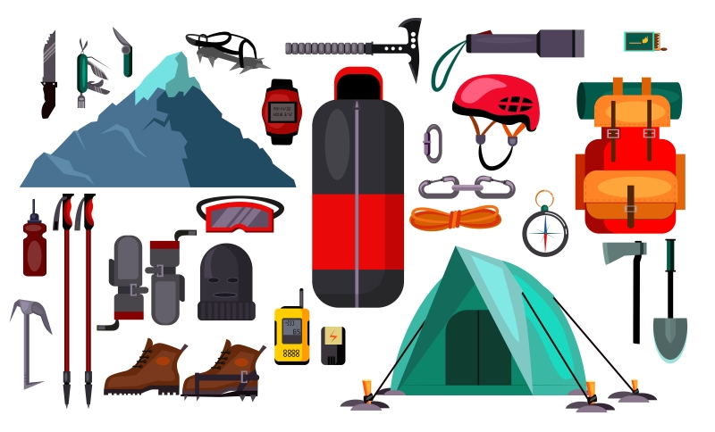

Supongamos un viaje corto para el montañista, en el que no necesita considerar varios artículos, como una bolsa de dormir, su plan es viajar solo por unas pocas horas, tampoco considera escalar pendientes empinadas, por lo que decide llevar consigo una mochila pequeña ($W=7$), ahora debe decidir cuáles artículos llevar, conociendo el beneficio que le trae cada artículo realiza la siguiente lista:

Artículo

Beneficio

Peso

6

5

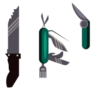

10

2

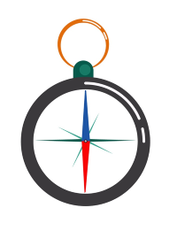

12

1

5

1

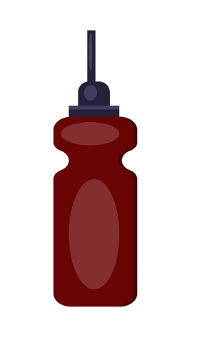

8

4

A partir de esta información, el montañista, debe tomar una decisión, para ello utiliza su función realizada con programación dinámica para resolver su problema, por lo que el planteamiento queda como sigue:

```python
# Ejemplo simple
val = [6, 10, 12, 5, 8]   # p_j (beneficios)
wt =  [5,  2,  1, 1, 4]   # w_j (pesos)
W = 7                     # peso máximo
N = len(val)              # número de artículos

max_beneficio, K = knapsackDP(W, wt, val, N)

print("El beneficio optimizado dentro de la mochila es: ", max_beneficio)
```

```
El beneficio optimizado dentro de la mochila es:  30
```

```python
print('\n'.join([''.join(['{:4}'.format(item) for item in row]) for row in K]))
```

```
   0   0   0   0   0   0   0   0
   0   0   0   0   0   6   6   6
   0   0  10  10  10  10  10  16
   0  12  12  22  22  22  22  22
   0  12  17  22  27  27  27  27
   0  12  17  22  27  27  27  30
```

El tiempo de ejecución de la función anterior está dominado por las iteraciones $N+1$ del primer ciclo `for` (ya que las listas de Python están indexadas desde 0), cada una de las cuales contiene como máximo $W+1$ iteraciones donde una nueva solución de un subproblema se calcula. Esto produce un tiempo de ejecución total de $O(NW)$. Por lo tanto, hemos presentado un algoritmo pseudopolinomial para KP. El requisito de espacio necesario de esta implementación también sería $O(NW)$. Cabe señalar que esta función solo calcula el valor de solución óptima $z^*$ pero no devuelve explícitamente el correspondiente conjunto de solución óptima $X^*$, que por cierto corresponde a la selección de elementos $j=2,3,5$ (con valores de beneficio $10$, $12$ y $8$ respectivamente).

Es decir, la selección óptima de artículos a llevar en la mochila, es:

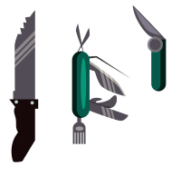

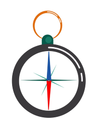

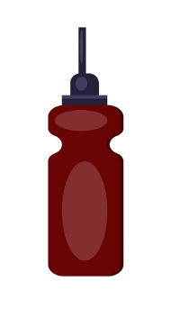

# Enfoque cuántico

El problema de optimización resultante, como se plantea en las ecuaciones (1), (2) y (3), se puede asignar a un **Hamiltoniano** cuyo estado fundamental (o estado de mínima energía) corresponde a la **solución óptima**. Por lo que el problema debe plantearse en forma de Hamiltoniano. Para esto existen ya muchas propuestas de modelos, veamos brevemente una.

En [A. Lucas (2014)] se presenta un Hamiltoniano simple para el problema de la mochila: Sea $y_r$ para $1 \leq r \leq W $ una variable binaria que es $1$ si el peso final de la mochila es $r$, y $0$ en caso contrario. La solución propuesta consiste en definir $H = H_A + H_B$, con

$$H_A=A\left(1-\sum^{W}_{r=1}y_r\right)^2+A\left(\sum^{W}_{r=1}r\,y_r-\sum^{N}_{j=1}w_{j}x_{j}\right)^2$$

que hace cumplir que el peso solo puede tomar un valor y que el peso de los artículos en la mochila es igual al valor que afirmamos que tenía, y finalmente

$$H_B=-B\sum^{N}_{j=1}p_{j}x_{j}$$

Como requerimos que no sea posible encontrar una solución donde $H_A$ sea quebrantada débilmente a expensas de que $H_B$ se vuelva más negativo, entonces solicitamos que $0<B \, max(p_j)<A$ (es decir, agregar un elemento a la mochila, que la hace demasiado pesada, no está permitido). El número de qubits requerido es $N + \lfloor1 + log_2 \; W \rfloor$ (usando el truco de logaritmo de [A. Lucas (2014)]).

Podemos aplicar una **Optimización binaria cuadrática sin restricciones** (Quadratic Unconstrained Binary Optimization, QUBO) para resolver el problema, ya que los acoplamientos del Hamiltoniano son muy grandes y las interacciones son generales. El Hamiltoniano con estas adecuaciones se formula en [A. Lucas (2019)] como un QUBO.

Debemos resolver el QUBO varias veces para diferentes opciones de valores objetivo para resolver completamente el problema de optimización NP-hard y esto solo aumentará el tiempo de ejecución del algoritmo en un factor de $log(N \; max(p_j)) $, en el peor de los casos [A. Lucas (2019)].

Plantear estos Hamiltonianos no es tarea fácil, y una vez planteados, se debe hacer el mapeo para resolverlo en una computadora cuántica que trabaja con [circuitos cuánticos](https://en.wikipedia.org/wiki/Quantum_circuit), como lo son los dispositivos de IBM.

Qiskit se ha encargado de generar librerías dentro de su SDK que permiten resolver una gama de problemas bastante amplia, al contar con implementaciones para tal efecto y nos permite acceder a estas funcionalidades con poco código de alto nivel. Un ejemplo de esto es el módulo llamado [Qiskit Optimization](https://qiskit.org/documentation/apidoc/qiskit_optimization.html), el cual es capaz de resolver problemas de optimización como se plantea en general en la sección anterior llamada Problema de optimización.

## Módulo Qiskit Optimization

El [módulo de optimización de Qiskit](https://qiskit.org/documentation/apidoc/qiskit_optimization.html) cubre todo el rango, desde el modelado de alto nivel de problemas de optimización, con conversión automática de problemas a diferentes representaciones requeridas, hasta un conjunto de algoritmos de optimización cuántica fáciles de usar que están listos para ejecutarse en simuladores clásicos, así como en dispositivos cuánticos reales a través de Qiskit.

Este módulo permite el modelado fácil y eficiente de problemas de optimización utilizando [docplex](https://developer.ibm.com/docloud/documentation/optimization-modeling/modeling-for-python/). Una interfaz uniforme, así como la conversión automática entre diferentes representaciones de problemas, permite a los usuarios resolver problemas utilizando un gran conjunto de algoritmos.

El módulo de optimización de Qiskit admite programas cuadráticos restringidos cuadráticamente (para simplificar los llamamos programas cuadráticos o *Quadratic Programs*) con variables binarias, enteras y continuas, así como restricciones de igualdad y desigualdad. Esta clase de problemas de optimización tiene una gran cantidad de aplicaciones relevantes, sin dejar de ser eficientemente representable por matrices y vectores. Esta clase cubre algunas subclases muy interesantes, desde programas cuadráticos continuos convexos (Convex Continuous Quadratic Programs), que pueden resolverse eficientemente mediante algoritmos de optimización clásicos, hasta problemas de optimización binaria cuadrática no restringida (Quadratic Unconstrained Binary Optimization, QUBO), que cubren muchos problemas NP-completos, es decir, clásicamente intratables.

## Convertidores para programas cuadráticos

Los problemas de optimización en el módulo de optimización de Qiskit se representan con la clase `QuadraticProgram`, que es una representación genérica y poderosa de los problemas de optimización. En general, los algoritmos de optimización se definen para una determinada formulación de un programa cuadrático y necesitamos convertir nuestro problema al tipo correcto.

Por ejemplo, Qiskit proporciona varios algoritmos de optimización que pueden manejar problemas de optimización binaria cuadrática sin restricciones (QUBO). Estos se asignan a Hamiltonianos de tipo [Ising](https://en.wikipedia.org/wiki/Ising_model). Para esta optimización, se pueden utilizar algoritmos comúnmente conocidos como VQE o QAOA como rutina subyacente.

Para más detalle consulta el tutorial [Converters for Quadratic Programs](https://qiskit.org/documentation/optimization/tutorials/02_converters_for_quadratic_programs.html).

## Resolviendo con Qiskit

Instalación del SDK Qiskit y del módulo de Optimización:

```python
#!pip install qiskit
#!pip install qiskit-optimization
```

Hagamos las importaciones necesarias:

```python
from qiskit_optimization.applications import Knapsack             # clase principal para este tipo de problema
from qiskit.algorithms import QAOA, NumPyMinimumEigensolver
from qiskit_optimization.algorithms import MinimumEigenOptimizer
from qiskit.utils import algorithm_globals, QuantumInstance
from qiskit import Aer, BasicAer
```

Resolveremos una instancia del problema de la mochila con 5 artículos, como se vio en el enfoque clásico, usando diferentes solucionadores de Qiskit.

```python
values  = [6, 10, 12, 5, 8]   # lista de los valores de beneficio de los artículos
weights = [5,  2,  1, 1, 4]   # lista de pesos de artículos
max_weight = 7                # capacidad máxima de peso (capacidad de la mochila)

# definir el problema que queremos resolver
# Usamos la clase Knapsack que es parte del módulo qiskit-optimization
problem = Knapsack(values = values, weights = weights, max_weight = max_weight)
```

Convirtamos la instancia del problema de la mochila en un `QuadraticProgram`.

La clase `QuadraticProgram` es a que nos ayuda a representar un problema de optimización dentro de Qiskit.

Consulta el tutorial sobre [Quadratic Programs](https://qiskit.org/documentation/optimization/tutorials/01_quadratic_program.html) para obtener más detalles.

```python
qp = problem.to_quadratic_program()

# mostremos los detalles del programa cuadrático
print(qp)
```

```
\ This file has been generated by DOcplex
\ ENCODING=ISO-8859-1
\Problem name: Knapsack

Maximize
 obj: 6 x_0 + 10 x_1 + 12 x_2 + 5 x_3 + 8 x_4
Subject To
 c0: 5 x_0 + 2 x_1 + x_2 + x_3 + 4 x_4 <= 7

Bounds
 0 <= x_0 <= 1
 0 <= x_1 <= 1
 0 <= x_2 <= 1
 0 <= x_3 <= 1
 0 <= x_4 <= 1

Binaries
 x_0 x_1 x_2 x_3 x_4
End
```

Desde el `QuadraticProgram` que se muestra arriba, podemos ver que define 5 variables $x_j$ (indexadas en 0) y que están sujetas a la restricción $0\leq x_j\leq 1$, ya que queremos que sus valores sean solamente *elegido =* $1$ o *no elegido =* $0$, como se define en la ecuación (3).

También especifica lo que queremos maximizar:

$$6x_0 + 10x_1 + 12x_2 + 5x_3 + 8x_4$$

que debe aplicarse como se define en la ecuación (2).

Ahora solucionemos el problema con **diferentes optimizadores** proporcionados por Qiskit.

Encontrar la solución a un QUBO (problema de optimización binaria cuadrática no restringida) es equivalente a encontrar el estado fundamental de un Hamiltoniando Ising correspondiente, que es un problema importante no solo en optimización, sino también en química cuántica y física. Para esta traducción, las variables binarias que toman valores en $\{0,1\}$ son reemplazadas por variables de espín que toman valores en $\{−1, +1\}$, lo que permite reemplazar las variables de espín resultantes por [matrices Z de Pauli](https://en.wikipedia.org/wiki/Pauli_matrices), y por lo tanto, un Hamiltoniano Ising. Para obtener más detalles sobre este mapeo, consulta [A. Lucas (2014)].

Qiskit proporciona conversión automática de un `QuadraticProgram` adecuado a un Hamiltoniano de tipo Ising, que luego permite aprovechar todo el sistema de resolución con `MinimumEigenSolver`, como: `VQE`, `QAOA` o `NumpyMinimumEigensolver` (método exacto clásico).

Consulta [Minimum Eigen Optimizer](https://qiskit.org/documentation/optimization/tutorials/03_minimum_eigen_optimizer.html) para obtener más detalles.

### Resolver con `NumPyMinimumEigensolver`, referencia clásica

Resolvamos el problema. Primero clásicamente.

Ahora podemos usar el problema que construimos anteriormente sin tener en cuenta los detalles de cómo se creó, de eso se encarga Qiskit. Configuramos el algoritmo para resolver con la clase `NumPyMinimumEigensolver`, de esta manera, tendremos una referencia clásica, algo con que comparar los resultados obtenidos con computación cuántica. El problema está fijado para ["ising"](https://arxiv.org/pdf/2009.09208.pdf). No se requiere backend (simulador o dispositivo real), ya que se calcula de forma clásica sin utilizar el cálculo cuántico. El resultado se devuelve como un diccionario.

```python
# Numpy Eigensolver

meo = MinimumEigenOptimizer(min_eigen_solver=NumPyMinimumEigensolver())
result = meo.solve(qp)
print('resultado:\n', result)
print('\nsolución:\n', problem.interpret(result))
```

```
resultado:
 optimal function value: 30.0
optimal value: [0. 1. 1. 0. 1.]
status: SUCCESS

solución:
 [1, 2, 4]
```

En el la lista `optimal value: [0. 1. 1. 0. 1.]`, queda clara la elección de ítems que resuelven este *knapsack problem*, es decir, los artículos con valores $10$, $12$ y $8$ respectivamente, lo que suma un valor total dentro de la mochila del montañista igual a $30$. La misma solución que se obtuvo con la programación dinámica.

### Resolver con `QAOA`

QAOA (algoritmo de optimización cuántica aproximada) introducido por [Farhi et al. (2014)] es un algoritmo cuántico que intenta resolver este tipo de problemas combinatorios.

Es un algoritmo variacional que utiliza una unitaria $U(\beta,\gamma)$ caracterizada por los parámetros $(\beta,\gamma)$ para preparar un estado cuántico $\ket{\psi(\beta,\gamma)}$. El objetivo del algoritmo es encontrar parámetros óptimos $(\beta_{opt},\gamma_{opt})$ de modo que el estado cuántico $\ket{\psi(\beta_{opt},\gamma_{opt})}$ codifique la solución al problema.

Para más detalles consulta el libro de texto de Qiskit: [Solving combinatorial optimization problems using QAOA](https://qiskit.org/textbook/ch-applications/qaoa.html#Combinatorial-Optimization-Problem).

Ahora usemos QAOA (Quantum Approximate Optimization Algorithm) para resolver nuestro problema de la mochila, para ello usaremos la clase `QAOA` que define el planteamiento del problema con las características que este algoritmo necesita.

Necesitaremos un backend (un [simulador](https://qiskit.org/documentation/tutorials/simulators/1_aer_provider.html)) para ejecutar el algoritmo cuántico en Qiskit, en este ejemplo usaremos `qasm_simulator` y lo podemos acceder a través del módulo [Aer](https://qiskit.org/documentation/apidoc/aer.html).

```python
# QAOA

seed = 123
algorithm_globals.random_seed = seed
qinstance = QuantumInstance(backend=Aer.get_backend('qasm_simulator'), shots=1000,
                            seed_simulator=seed, seed_transpiler=seed)

meo = MinimumEigenOptimizer(min_eigen_solver=QAOA(reps=1, quantum_instance=qinstance))
result = meo.solve(qp)
print('resultado:\n', result)
print('\nsolución:\n', problem.interpret(result))
print('\ntiempo de ejecución:', result.min_eigen_solver_result.optimizer_time)
```

```
resultado:
 optimal function value: 30.0
optimal value: [0. 1. 1. 0. 1.]
status: SUCCESS

solución:
 [1, 2, 4]

tiempo de ejecución: 0.47572851181030273
```

Como podemos ver, usando ambos solucionadores obtenemos el mismo resultado en nuestro problema de ejemplo:

$$[1, 2, 4]$$

Esto indica que estos artículos son los que sin exceder el peso máximo se pueden llevar en la mochila, y se maximizan los valores de los ítems elegidos, estos números son los índices de los elementos seleccionados (recuerda que está indexado desde 0).

### ¿Qué pasa con el Hamiltoniano?

Si quieres revisar el Hamiltoniano que se genera durante el proceso de resolución (por el `MinimumEigenOptimizer`), es necesario realizar este paso intermedio nosotros mismos, es decir,

```python
from qiskit_optimization.converters import QuadraticProgramToQubo

# forma QUBO intermedia del problema de optimización
converter = QuadraticProgramToQubo()
qubo = converter.convert(qp)

# mostremos los detalles de la forma QUBO
print(qubo)
```

```
\ This file has been generated by DOcplex
\ ENCODING=ISO-8859-1
\Problem name: Knapsack

Minimize
 obj: - 2946 x_0 - 1186 x_1 - 600 x_2 - 593 x_3 - 2360 x_4 - 588 c0@int_slack@0
      - 1176 c0@int_slack@1 - 2352 c0@int_slack@2 + [ 2100 x_0^2 + 1680 x_0*x_1
      + 840 x_0*x_2 + 840 x_0*x_3 + 3360 x_0*x_4 + 840 x_0*c0@int_slack@0
      + 1680 x_0*c0@int_slack@1 + 3360 x_0*c0@int_slack@2 + 336 x_1^2
      + 336 x_1*x_2 + 336 x_1*x_3 + 1344 x_1*x_4 + 336 x_1*c0@int_slack@0
      + 672 x_1*c0@int_slack@1 + 1344 x_1*c0@int_slack@2 + 84 x_2^2
      + 168 x_2*x_3 + 672 x_2*x_4 + 168 x_2*c0@int_slack@0
      + 336 x_2*c0@int_slack@1 + 672 x_2*c0@int_slack@2 + 84 x_3^2 + 672 x_3*x_4
      + 168 x_3*c0@int_slack@0 + 336 x_3*c0@int_slack@1 + 672 x_3*c0@int_slack@2
      + 1344 x_4^2 + 672 x_4*c0@int_slack@0 + 1344 x_4*c0@int_slack@1
      + 2688 x_4*c0@int_slack@2 + 84 c0@int_slack@0^2
      + 336 c0@int_slack@0*c0@int_slack@1 + 672 c0@int_slack@0*c0@int_slack@2
      + 336 c0@int_slack@1^2 + 1344 c0@int_slack@1*c0@int_slack@2
      + 1344 c0@int_slack@2^2 ]/2 + 2058
Subject To

Bounds
 0 <= x_0 <= 1
 0 <= x_1 <= 1
 0 <= x_2 <= 1
 0 <= x_3 <= 1
 0 <= x_4 <= 1
 0 <= c0@int_slack@0 <= 1
 0 <= c0@int_slack@1 <= 1
 0 <= c0@int_slack@2 <= 1

Binaries
 x_0 x_1 x_2 x_3 x_4 c0@int_slack@0 c0@int_slack@1 c0@int_slack@2
End
```

Veamos el Hamiltoniano de tipo Ising de este problema:

```python
# Hamiltoniano y offset
operator, offset = qubo.to_ising()

print(f'cantidad de qubits: {operator.num_qubits}, offset: {offset}\n')

print(operator)
```

```
cantidad de qubits: 8, offset: 1071.5

-504.0 * ZIIIIIII
- 252.0 * IZIIIIII
+ 168.0 * ZZIIIIII
- 126.0 * IIZIIIII
+ 84.0 * ZIZIIIII
+ 42.0 * IZZIIIII
- 500.0 * IIIZIIII
+ 336.0 * ZIIZIIII
+ 168.0 * IZIZIIII
+ 84.0 * IIZZIIII
- 123.5 * IIIIZIII
+ 84.0 * ZIIIZIII
+ 42.0 * IZIIZIII
+ 21.0 * IIZIZIII
+ 84.0 * IIIZZIII
- 120.0 * IIIIIZII
+ 84.0 * ZIIIIZII
+ 42.0 * IZIIIZII
+ 21.0 * IIZIIZII
+ 84.0 * IIIZIZII
+ 21.0 * IIIIZZII
- 247.0 * IIIIIIZI
+ 168.0 * ZIIIIIZI
+ 84.0 * IZIIIIZI
+ 42.0 * IIZIIIZI
+ 168.0 * IIIZIIZI
+ 42.0 * IIIIZIZI
+ 42.0 * IIIIIZZI
- 627.0 * IIIIIIIZ
+ 420.0 * ZIIIIIIZ
+ 210.0 * IZIIIIIZ
+ 105.0 * IIZIIIIZ
+ 420.0 * IIIZIIIZ
+ 105.0 * IIIIZIIZ
+ 105.0 * IIIIIZIZ
+ 210.0 * IIIIIIZZ
```

### Resolver con `VQE`

VQE es una aplicación del método variacional de la mecánica cuántica:

$$\lambda_{min}\leq\langle H\rangle_{\psi}=\bra{\psi}H\ket{\psi} = \sum_{i=1}^{N}\lambda_i|\braket{\psi_i}{\psi}|^2$$

La ecuación anterior es conocida como el principio variacional, es importante señalar que esto implica que el valor esperado de cualquier función de onda siempre será al menos el valor propio mínimo asociado con $H$. Además, el valor esperado del estado propio $\ket{\psi_{min}}$ esta dado por $\lambda_{min}$. Por lo tanto, como se esperaba $\langle H\rangle_{\psi}=\lambda_{min}$.

Cuando el Hamiltoniano de un sistema es descrito por la matriz hermitiana $H$, la energía del estado fundamental de ese sistema, $E_{ground}$, es el valor propio más pequeño asociado con $H$. Seleccionando arbitrariamente una función de onda $\ket{psi}$ (llamada [ansatz](https://en.wikipedia.org/wiki/Ansatz)) como una estimación inicial que se aproxima a $\ket{\psi_{min}}$, calculando su valor esperado, $\leq\langle H\rangle_{\psi}$, y actualizando iterativamente la función de onda, se pueden obtener límites arbitrariamente estrechos en la energía del estado fundamental de un Hamiltoniano.

Para más detalles consulta el libro de texto de Qiskit: [Simulating Molecules using VQE](https://qiskit.org/textbook/ch-applications/vqe-molecules.html).

Ahora usemos el Solucionador Propio Cuántico Variacional (Variational Quantum Eigensolver, VQE) para resolver el problema. Especifiquemos el optimizador y la forma variacional que se utilizará.

Usamos la clase `VQE` que define el planteamiento del problema con las características que este algoritmo necesita.

A esta instancia será necesario especificarle un optimizador, existen varios, pero aquí usaremos `SPSA`, detalles de la eficiencia de los diferentes optimizadores se pueden consultar en este tutorial: [Monitoring VQE convergence](https://qiskit.org/documentation/tutorials/algorithms/02_vqe_convergence.html).

VQE necesita un circuito ansatz y para ello Qiskit nos proporciona una variedad de estos, en este caso usaremos `EfficientSU2`. Otras clases que definen circuitos ansatz pueden consultarse [aquí](https://qiskit.org/documentation/apidoc/circuit_library.html#n-local-circuits), y también puedes definir tu propio ansatz y utilizarlo con la clase `VQE`.

También usaremos el `qasm_simulator`, para ejecutar nuestro algoritmo cuántico.

```python
from qiskit.algorithms import VQE
from qiskit.algorithms.optimizers import SPSA
from qiskit.circuit.library import EfficientSU2
```

```python
# VQE

seed = 123
algorithm_globals.random_seed = seed
qinstance = QuantumInstance(backend=Aer.get_backend('qasm_simulator'), shots=1000,
                            seed_simulator=seed, seed_transpiler=seed)

ansatz = EfficientSU2(operator.num_qubits, reps=2, entanglement='circular')
optimizer = SPSA(maxiter=15)

meo = MinimumEigenOptimizer(min_eigen_solver=VQE(ansatz = ansatz, optimizer = optimizer, quantum_instance = qinstance))
result = meo.solve(qp)
print('result:\n', result)
print('\nsolution:\n', problem.interpret(result))
print('\ntime:', result.min_eigen_solver_result.optimizer_time)
```

```
result:
 optimal function value: 30.0
optimal value: [0. 1. 1. 0. 1.]
status: SUCCESS

solution:
 [1, 2, 4]

time: 12.529057741165161
```

# Ejercicio: Inversiones

Imagina que tienes un presupuesto de $20$ y lo quieres usar para invertir en la bolsa de valores [NASDAQ](https://www.nasdaq.com/), después de una investigación que realizaste, has llegado a la conclusión de que lo más conveniente es invertir en acciones de empresas de tecnología, la información recopilada de tu investigación se resume en la siguiente tabla:

| Empresa | Ticker | Inversión | Rendimiento |
| --- | --- | --- | --- |
| Apple | AAPL | 3 | 10 |
| Amazon | AMZN | 5 | 6 |
| Netflix | NFLX | 6 | 8 |
| Facebook | F | 7 | 3 |
| IBM | IBM | 5 | 11 |

**Nota**: Esto es solo un ejemplo y no representa un consejo financiero, los datos usados aquí son números aleatorios que fueron seleccionaos para que el problema tuviera solución.

### Parte 1:

- ¿Cómo se plantea el problema de optimización para este problema en particular? (revisa las ecuaciones (1), (2) y (3))
- Identifica las variables
- Identifica los pesos y los valores de beneficio

### Parte 2:

- Resuelve el problema con un enfoque cuántico
- Plantea el problema usando la clase `Knapsack`

### Parte 3:

- Compara tu resultado con una solución clásica (usando Qiskit)

Para **tomar en cuenta el riesgo** puedes dirigirte a la documentación de [Qiskit Finance](https://qiskit.org/documentation/finance/), este otro módulo de Qiskit permite planteamientos más interesantes, las clases en este módulo están preparadas para resolver problemas más enfocados a las finanzas.

Un ejemplo más completo que si toma en cuenta el riesgo así como información de las series de tiempo de los precios de los tickers, se encuentra en particular en el tutorial: [Portfolio Optimization](https://qiskit.org/documentation/tutorials/finance/01_portfolio_optimization.html)

### Parte 4:

¿En qué problemas podrías usar las versiones acotada y no acotada del KP?

# Referencias

- [H. Kellerer, U. Pferschy, D. Pisinger (2004). Knapsack Problems. Springer-Verlag Berlin Heidelberg. ISBN 978-3-642-07311-3](https://www.springer.com/gp/book/9783540402862)
- [S. Martello, P. Toth (1990). Knapsack Problems: Algorithms and Computer Implementations. John Wiley & Sons Ltd. ISBN 0-471-92420-2](https://books.google.com/books/about/Knapsack_Problems.html?id=0dhQAAAAMAAJ)
- [A. Lucas, Ising formulations of many NP problems, Front. Phys., 12 (2014).](https://arxiv.org/abs/1302.5843)
- [A. Lucas, Hard combinatorial problems and minor embeddings on lattice graphs, Quantum Information Processing, vol. 18, no. 7, (2019)](https://arxiv.org/abs/1812.01789)
- [Qiskit’s optimization module](https://qiskit.org/documentation/apidoc/qiskit_optimization.html)
- [Converters for Quadratic Programs](https://qiskit.org/documentation/optimization/tutorials/02_converters_for_quadratic_programs.html)
- [Quadratic Programs](https://qiskit.org/documentation/optimization/tutorials/01_quadratic_program.html)
- [Minimum Eigen Optimizer](https://qiskit.org/documentation/optimization/tutorials/03_minimum_eigen_optimizer.html)
- [Farhi, Edward, Jeffrey Goldstone, and Sam Gutmann. A quantum approximate optimization algorithm, (2014)](https://arxiv.org/abs/1411.4028)
- [Solving combinatorial optimization problems using QAOA](https://qiskit.org/textbook/ch-applications/qaoa.html#Combinatorial-Optimization-Problem)
- [Simulating Molecules using VQE](https://qiskit.org/textbook/ch-applications/vqe-molecules.html)
- [Knapsack problem, WIP qiskit tutorial](https://github.com/Qiskit/qiskit-optimization/pull/202)
- [Imagenes de libre acceso tomadas de **freepik**](https://www.freepik.com/)